# Introductions: GVPT 429K

# Are you in the right room?

- This is GVPT 429K: Researching Contentious Politics
- Instructor info:
  - Neil Lund (nlund@umd.edu)
  - Office 1140C Tydings Hall (in the suite behind the glass doors)
  - Office Hours: Tu: 3:30 - 5:00, Thu: 11:00 - 12:30, MWF: by appointment

# Goals of the course

By the end of the semester, you should be able to:

- Define contentious politics and identify the major motivating questions and key theories in the field.
- Critically assess the methods and major data sources for studying contentious politics and have a sound understanding of their strengths and weaknesses.
- Collect, clean, and analyze data on contentious politics to produce original research on a real-world instance of contentious political behavior.

# Required Materials

- Laptop with R-Studio installed
- Readings (provided through ELMS)
- Additional readings/data provided through ELMS or github

# Major grades

- **Participation (10%):** graded holistically based on engagement (not just attendance)
- **Response papers/Short essays** **(30%)**: responses to the reading/short analyses
- **Assignments/Quizzes (25%):** R-homework and short reading quizzes
- **Final Paper/Presentation (35%):** data-driven analysis of a contentious event, wave, organization etc.
  - Presentations in the last week of class
  - Final memo due on final exam date

## What is contentious politics?

## Contentious politics

- Coordinated claims-making that impinges on someone else’s interest
- Must be:
  - Collective
  - Deliberate
  - Political (involves government as a target or audience, but not as the primary actor)
  - At least some non-institutional component

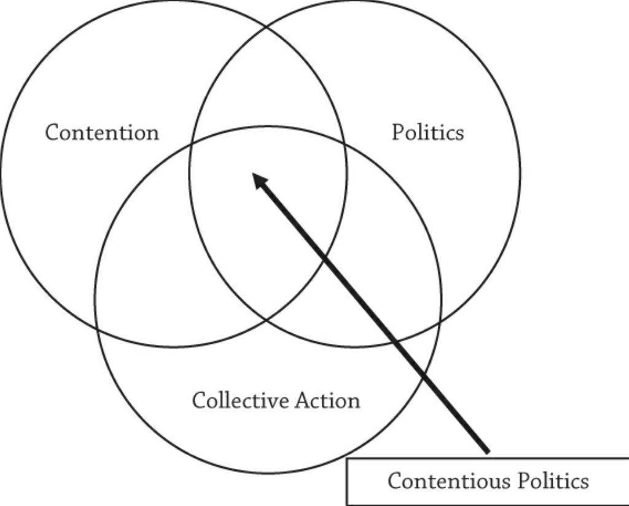

## Defining the scope

- Originates with research on protests and social movements…but!
- Social movements are considered one of several tools in the “contentious repertoire”

### 17th century contention

[figure not shown]

Hudibras Encounters the Skimmington (engraving by William Hogarth)

### Social movements as historically contingent

Contentious politics is universal but:

- Precursors to social movements were more parochial, concerned immediate local interests, worked by direct influence (public humiliation, destruction of property, physical pain, or state overthrow)
- Social movements are tied to the emergence of liberal democracy, industrialization and an urban middle class, and the consolidation of nation-states with centralized bureaucracies.
- They don’t happen everywhere, and they might eventually become as archaic as chivaree
- Social movements belong to a class of actions that also includes: strikes, riots, terrorism, revolutions etc.

## Problems, methods, and themes

### Collective Action Problem(s)

- Olson: the demand for collective action will generally exceed the supply
  - Contentious actors face a Free-Rider problem (why?)
  - Overcoming it typically requires organization and resources

### Contentious Interaction

- Contentious politics involves groups with disparate interests
- Contentious politics takes place in a social/political/economic context
- Contentious politics involves governments and is shaped by interactions with authorities

### Temporal and spatial patterns

Contentious actions come in waves

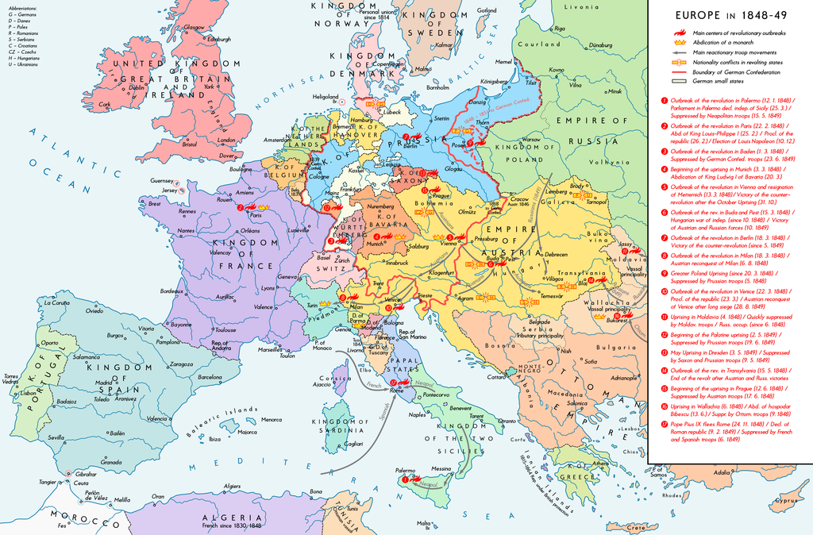

Map of the Revolutions of 1848

### Identities, interests and frames

- Collective actors share identities or they work to form one
- Even if we can solve the free rider problem, we need to agree on what to do, who we are, who we represent, and who we oppose

### Research Methods

- Some similarities in research methods across issue areas:
  - Event catalogs
  - Organizational ecology, network analysis
  - Surveys and individual biographies
  - Process tracing, comparative methods

## Next week: where does collective action come from?

- Why do [people] rebel?
  - What kinds of conditions cause people to engage in contentious politics?
  - Are crowds “mad” or is collective action “rational” in some sense?

[figure not shown]